# Exponential Distribution vs CLT in R

Jackie Milhans

July 24, 2015

### Overview

In this project we investigate the exponential distribution in R and compare it with the Central Limit Theorem. The exponential distribution can be simulated in R with rexp(n, lambda) where lambda is the rate parameter. The mean of exponential distribution is 1/lambda and the standard deviation is also 1/lambda. Set lambda = 0.2 for all of the simulations. We investigate the distribution of averages of 40 exponentials. Note that we do a thousand simulations.

## Simulations

Illustrate via simulation and associated explanatory text the properties of the distribution of the mean of 40 exponentials.

We simulate the data using a 1000 x 40 matrix. With apply(), we get 1000 means of each of the 40 samples.

```r
#load ggplot
library(ggplot2)

#Set Seed for Reproducible Simulation
set.seed(99)

numSim <- 1000
lamda <- 0.2
n <- 40

theoMean <- 1/lamda
simData <- matrix(rexp(numSim*n, lamda), numSim)
xbar <- apply(simData, 1, mean)
```

## Sample Mean versus Theoretical Mean

Here we compare the sample mean versus the theoretical mean.

```r
#Empirical Mean
sampleMean <- mean(xbar)
sampleMean
```

```
## [1] 5.014808
```

```r
#Theoretical Mean
theoMean
```

```
## [1] 5
```

The sample mean is similar to the theoretical mean of the distribution.

```
## [1] 0.7685519
```

```
## [1] 0.7905694
```

## Distribution

Here, we check the sample data:

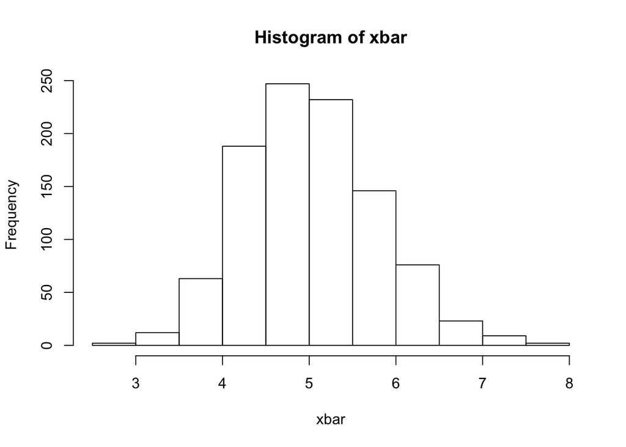

```r
hist(xbar)
```

We can see that the sample data is a normal distribution, in accordance with the central limit theorem.

## APPENDIX

### Appendix 1

The plot below shows the average of the means by the red line. This appears close to the theoretical mean of 5.

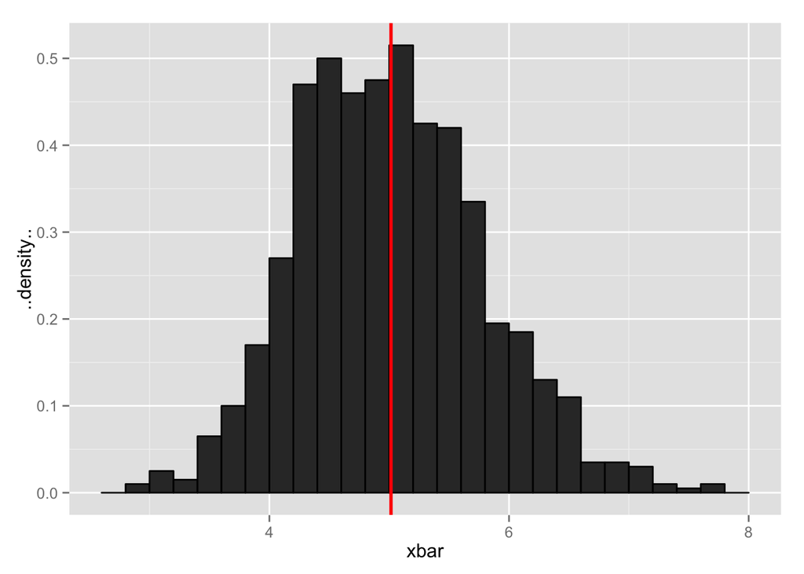

```r
ggplot() + aes(xbar, y=..density..) +
        geom_histogram(,binwidth=.2, color="black") +
        geom_vline(xintercept = mean(xbar), colour = 'red',size=1)
```

### Appendix 2

Check if the exponential distribution is normal.

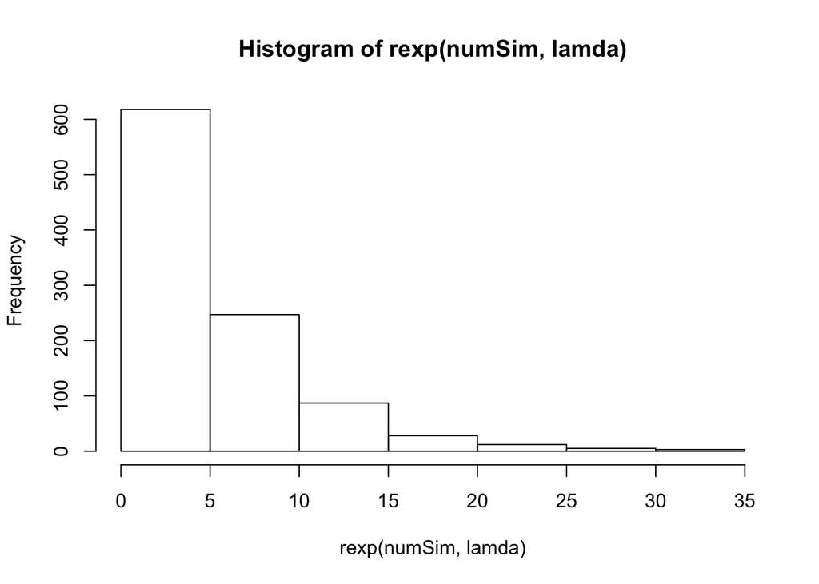

```r
hist(rexp(numSim, lamda))
```